# Clustering in R Quick Reference

Mark Niemann-Ross

2021-03-26

# About

## About This Document

This document provides brief explanations of the clustering functions available in Base R and the cluster package.

## Related Material

[The cluster package](https://cran.r-project.org/web/packages/cluster/index.html) is recommended for advanced operations. The cluster package is based on [Finding Groups in Data](https://onlinelibrary.wiley.com/doi/book/10.1002/9780470316801)

An exhaustive discussion of clustering can be found at [Machine Learning and AI foundations:clustering and association](https://linkedin-learning.pxf.io/lilclustering)

This Quick Reference is supplemental to courses on [LinkedIn Learning](https://www.linkedin.com/learning/r-for-data-science-lunchbreak-lessons/). A quick reference to [matrix math functions in R is here](http://niemannross.com/link/rmatrixqref). A quick reference to [plotting functions in R is here](http://niemannross.com/link/rplotqref). An index to all R functions covered at LinkedIn Learning is found [here](http://niemannross.com/link/rindex). The latest version of this quick reference is found [here](http://niemannross.com/link/rclusterqref). The source to this document is found on [github/mnr](https://github.com/mnr/R-for-Data-Science-Lunchbreak-Lessons). This document is available as Free Software under the terms of the [Free Software Foundation’s](http://www.gnu.org/) [GNU General Public License](https://www.r-project.org/COPYING).

## About Mark Niemann-Ross

[Mark](https://niemannross.com/) is an author for LinkedIn Learning and writes Science Fiction.

# Partitioning methods

Divide dataset into k clusters. (k is defined by researcher)

## *kmeans* : Partitioning around centroids

```r
# kmeans clusters data together, based on average distance from a centroid
# kmeans iterates through possible solutions to identify the best result

kmeans(quakes, 3)
```

```
## K-means clustering with 3 clusters of sizes 224, 389, 387
##
## Cluster means:
##         lat     long     depth      mag stations
## 1 -20.15759 179.2072 268.58482 4.523214 30.47768
## 2 -20.87082 178.5534  88.67866 4.752185 35.96915
## 3 -20.69432 180.5229 559.97933 4.544186 32.55556
##
## Clustering vector:
##    [1] 3 3 2 3 3 1 2 1 1 3 3 1 3 3 2 1 2 3 3 3 3 1 3 2 3 3 2 3 3 1 3 2 1 1 2 3 1
##   [38] 3 3 1 1 2 3 2 1 2 1 2 3 2 3 1 2 3 3 3 3 3 3 3 3 1 3 2 3 1 3 3 3 2 2 1 2 3
##   [75] 3 3 1 1 1 1 2 1 3 1 3 2 2 3 2 2 2 1 3 1 1 1 1 1 2 3 2 3 3 2 3 1 2 2 2 2 1
##  [112] 1 3 3 3 3 2 2 2 1 2 2 3 3 1 2 3 3 2 1 1 3 2 3 3 2 2 1 2 1 3 3 1 1 3 1 2 2
##  [149] 3 3 2 2 1 2 2 3 2 3 2 2 3 3 1 2 2 2 1 1 3 1 3 3 3 2 1 1 3 1 3 1 3 2 2 1 3
##  [186] 2 1 3 3 1 1 1 3 3 3 3 1 2 3 3 1 3 1 1 3 1 3 3 1 3 1 1 1 2 3 3 1 3 1 1 2 2
```

[output cut: 31 more lines]

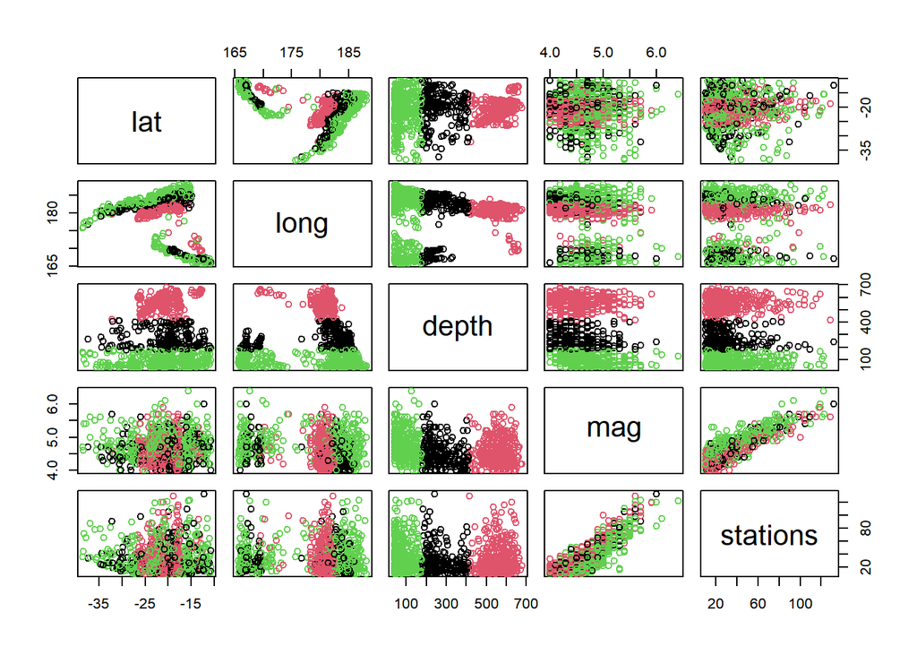

```r
# lots of information in the print from kmeans
# cluster sizes
# cl$centers - cluster means - shows the centroid for each cluster
# cl$cluster - clustering vector - shows which data points belong to which cluster
# cl$withinss - within cluster sum of squares - small SofS = more compact cluster


cl <- kmeans(quakes, 3)
plot(quakes, col = cl$cluster)
```

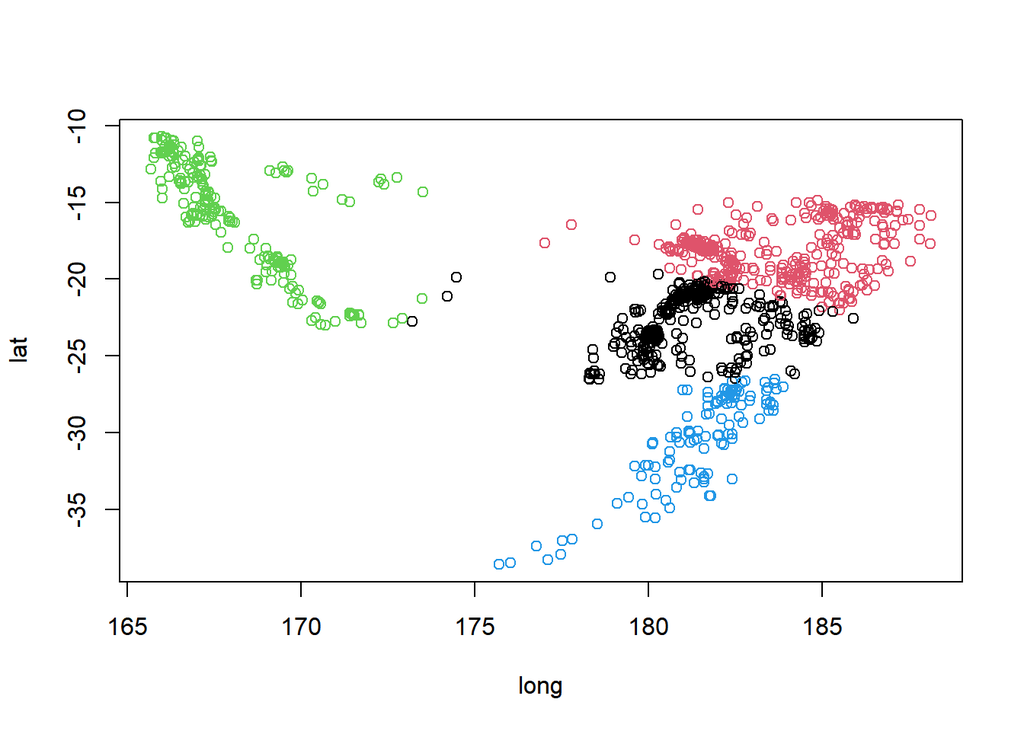

```r
# what are we looking at.

#simplify
simpleQuakes <- quakes[,c("long","lat")]
cl <- kmeans(simpleQuakes, 4)
plot(simpleQuakes, col = cl$cluster)
```

## *pam* : Partitioning Around Medoids

```r
simpleQuakes <- quakes[,c("long","lat")]
mypam <- pam(simpleQuakes,2) # assuming 2 medoids

# components of mypam - see pam.object
# for example...
mypam$medoids # coordinates of medoids
```

```
##        long    lat
## [1,] 182.02 -20.90
## [2,] 167.51 -15.36
```

```r
mypam$id.med # indices of medoids (i.e. simpleQuakes[mypam$id.med,])
```

```
## [1] 809 408
```

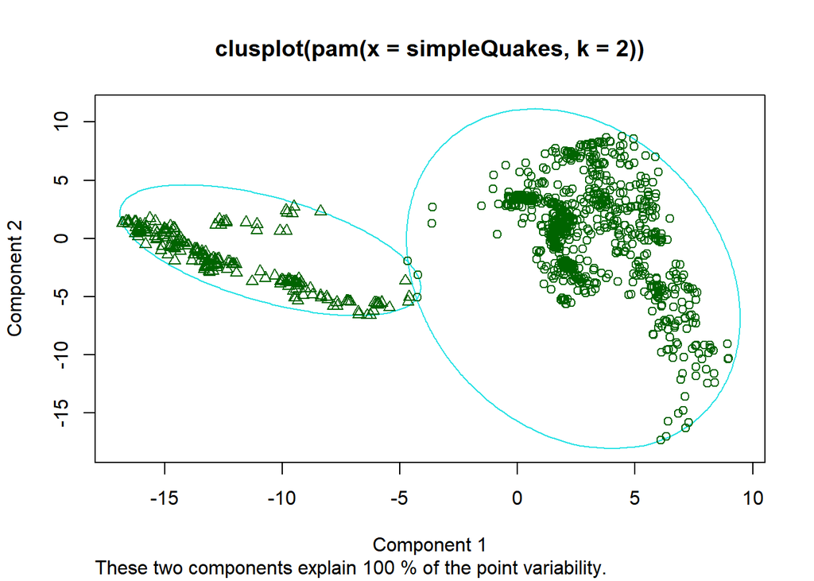

```r
# mypam$clustering # which points belong to which medoid
# same as... pam(simpleQuakes, 4, cluster.only = TRUE)


# plotting PAM
#plot(mypam)
#plot(mypam, ask = TRUE) # menu for plots

#map("worldHires","Fiji", xlim=c(160,190), ylim =c(-40,-15))
plot(mypam, which.plots = 1)
```

## *clara* : Clustering Large Applications

Clara is identical to pam() except subsamples the data before determining medoids.

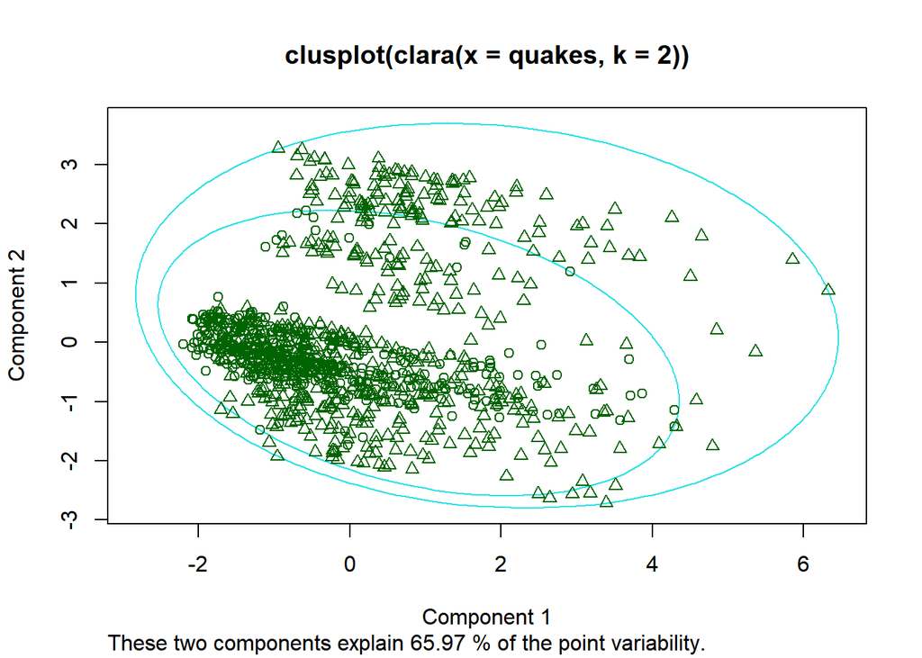

```r
myclara <- clara(quakes,2)
plot(myclara, which.plots = 1) #graph
```

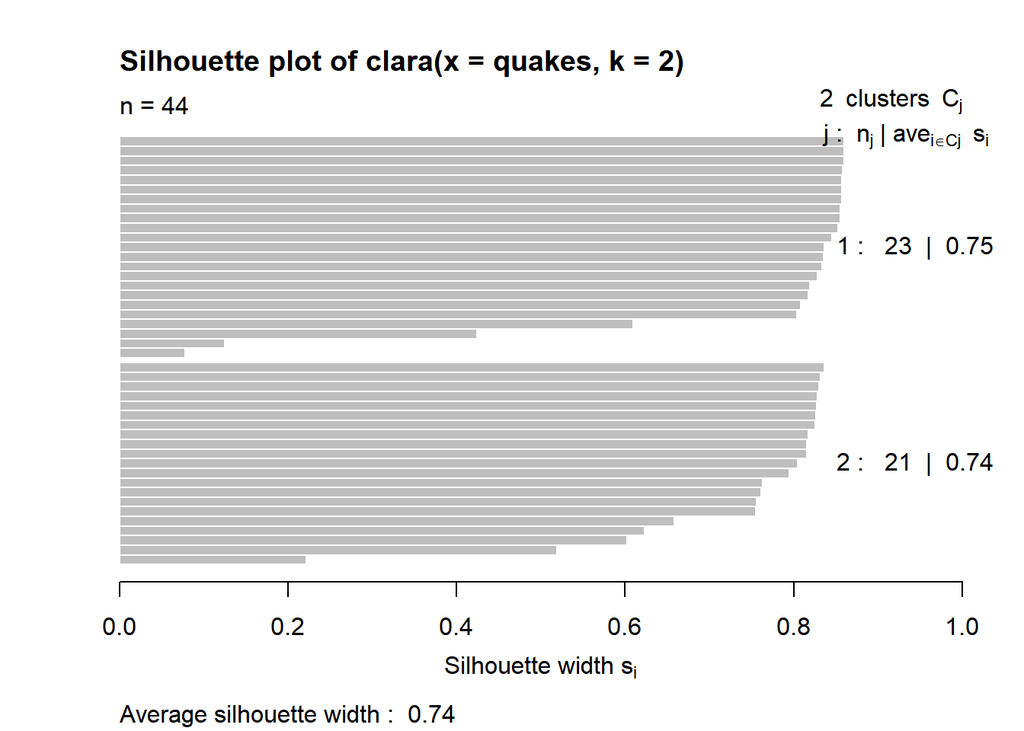

```r
plot(myclara, which.plots = 2) #silhoutte
```

## *fanny* : Fuzzy Analysis Clustering

```r
# downsample quakes for demonstration. from 500 to 25
simpleQuakes <- quakes[sample(nrow(quakes),25),c("long","lat")]

# create a fuzzy cluster with fanny
fuzCluster <- fanny(x = simpleQuakes, k = 3)
fuzCluster
```

```
## Fuzzy Clustering object of class 'fanny' :
## m.ship.expon.        2
## objective     25.31302
## tolerance        1e-15
## iterations          21
## converged            1
## maxit              500
## n                   25
## Membership coefficients (in %, rounded):
##     [,1] [,2] [,3]
## 738   71    8   20
## 997    6   88    6
## 893    4   92    4
## 635   16    4   80
## 302   16    5   79
## 924   29    9   61
## 444   21    5   74
## 149   88    2   10
## 322   21    4   75
## 301    8   84    7
## 887   25   56   19
## 412   22    5   73
## 918   35    5   59
## 898   67    5   28
## 17     6   89    5
## 118   19   64   18
## 687   32    9   58
## 541    9   84    7
## 605   41   31   29
## 19    86    3   11
## 624   86    3   11
## 520   68    8   23
## 535   31    6   63
## 415   20    5   75
## 936   24    8   68
## Fuzzyness coefficients:
## dunn_coeff normalized
##  0.6056892  0.4085338
## Closest hard clustering:
## 738 997 893 635 302 924 444 149 322 301 887 412 918 898  17 118 687 541 605  19
##   1   2   2   3   3   3   3   1   3   2   2   3   3   1   2   2   3   2   1   1
## 624 520 535 415 936
##   1   1   3   3   3
##
## Available components:
##  [1] "membership"  "coeff"       "memb.exp"    "clustering"  "k.crisp"
##  [6] "objective"   "convergence" "diss"        "call"        "silinfo"
## [11] "data"
```

```r
# this produces 4 parts: object, membership, fuzzyness, other components of object
fuzCluster$membership # percentage likelihood this point is part of this cluster.
```

```
##           [,1]       [,2]       [,3]
## 738 0.71458057 0.08269365 0.20272578
## 997 0.06492434 0.87565948 0.05941618
## 893 0.04479750 0.91516065 0.04004185
## 635 0.15974534 0.03797853 0.80227612
## 302 0.16317330 0.04569650 0.79113019
## 924 0.29272077 0.09428933 0.61298989
## 444 0.21139069 0.04989743 0.73871188
## 149 0.87650225 0.02440222 0.09909553
## 322 0.21295030 0.03835562 0.74869408
## 301 0.08106323 0.84496791 0.07396886
## 887 0.25023151 0.55503106 0.19473742
## 412 0.22038642 0.04659357 0.73302001
## 918 0.35291432 0.05476959 0.59231608
## 898 0.67053565 0.05147530 0.27798905
## 17  0.05735198 0.89128006 0.05136796
## 118 0.18801353 0.63657981 0.17540666
## 687 0.32323415 0.09325054 0.58351531
## 541 0.08541079 0.84097224 0.07361697
## 605 0.40786078 0.30647257 0.28566665
## 19  0.86448174 0.02879035 0.10672792
## 624 0.86464425 0.02652726 0.10882849
## 520 0.68195436 0.08310909 0.23493655
## 535 0.31098953 0.06259356 0.62641691
## 415 0.19766259 0.04973347 0.75260394
## 936 0.23545146 0.08206649 0.68248205
```

```r
fuzCluster$coeff # A low value of Dunn's coefficient indicates a very fuzzy clustering, whereas a value close to 1 indicates a near-crisp clustering
```

```
## dunn_coeff normalized
##  0.6056892  0.4085338
```

```r
fuzCluster$clustering # closest hard/crisp cluster
```

```
## 738 997 893 635 302 924 444 149 322 301 887 412 918 898  17 118 687 541 605  19
##   1   2   2   3   3   3   3   1   3   2   2   3   3   1   2   2   3   2   1   1
## 624 520 535 415 936
##   1   1   3   3   3
```

# Hierarchical methods

Start with cluster of one item, then build larger clusters (or the opposite)

## *hclust* : Hierarchical Clustering

```r
# builds a dendogram

# what is a distance matrix? (distance between points)
sampleQuakes <- quakes[sample(1:length(quakes$lat), 5),] # demonstrate a small set
sampleQuakes # here's the data
```

|  | lat | long | depth | mag | stations |
| --- | --- | --- | --- | --- | --- |
| 992 | -15.45 | 181.42 | 409 | 4.3 | 27 |
| 504 | -13.07 | 166.87 | 132 | 4.4 | 24 |
| 903 | -33.09 | 180.94 | 47 | 4.9 | 47 |
| 234 | -19.62 | 185.35 | 57 | 4.9 | 31 |
| 654 | -23.10 | 180.12 | 533 | 4.4 | 27 |

```r
dist(sampleQuakes) # here's the distance matrix
```

```
##           992       504       903       234
## 504 277.40832
## 903 362.98176  91.39483
## 234 352.06987  77.83741  23.59850
## 654 124.24260 401.35541 486.51487 476.05852
```

```r
# now here's a hierarchical cluster
hclust(dist(quakes)) # returns an hclust object
```

```
##
## Call:
## hclust(d = dist(quakes))
##
## Cluster method   : complete
## Distance         : euclidean
## Number of objects: 1000
```

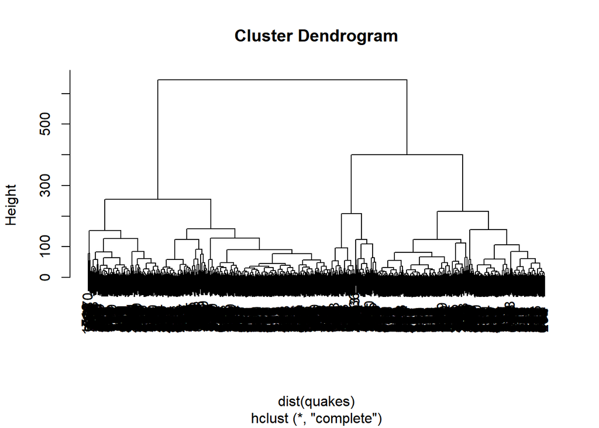

```r
plot(hclust(dist(quakes))) # overplot
```

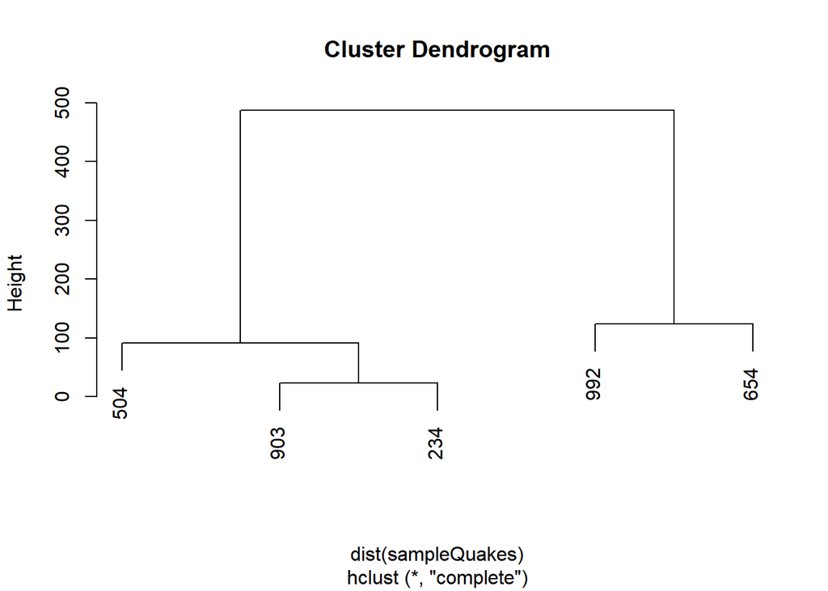

```r
plot(hclust(dist(sampleQuakes))) # more approachable
```

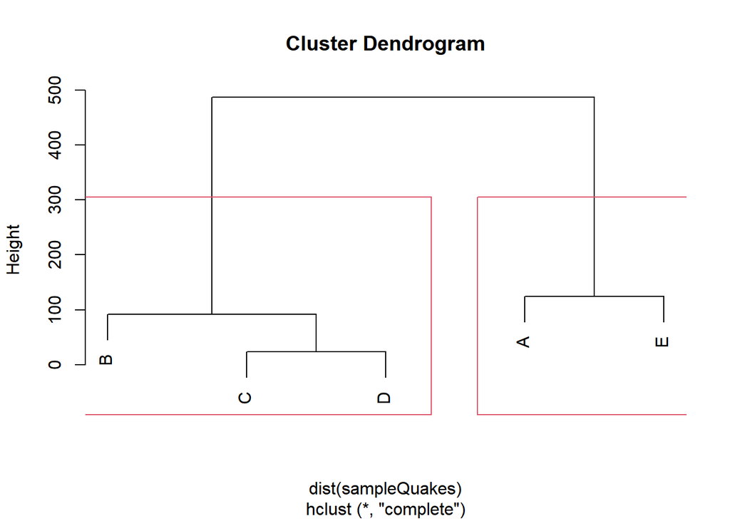

```r
# starts with one cluster per element
# Progressing up dendrogram produces larger clusters until one cluster at top
# Labels are row numbers.
plot(hclust(dist(sampleQuakes)),
     labels = c(LETTERS[1:length(sampleQuakes)])) # labeled points
rect.hclust(hclust(dist(sampleQuakes)), k=2) # draw box around clusters
```

## cutree: produce cluster from hierarchical

```r
# cutree produces clusters from hclust objects
cutree(hclust(dist(sampleQuakes)),k=2)
```

```
## 992 504 903 234 654
##   1   2   2   2   1
```

## *agnes* : Agglomerative Nesting

Agnes is a heirarchical method. It’s like hclust, but includes an agglomerative coefficient and banner plot. Agnes produces hclust objects and works with hclust functions. It sometimes requires as.hclust(). Unlike hclust, agnes doesn’t require dist().

agglomerative means start with clusers of n=1, then increase n

```r
agnes(quakes)
```

```
## Call:     agnes(x = quakes)
## Agglomerative coefficient:  0.9838927
## Order of objects:
##    [1]    1  590  680  169   61   83  577  731  811  841  674  800  188  280
##   [15]  424  849  940  561  253  356  700  363  703  568  981  689    4  161
##   [29]   10  660  665  135  941  173  247  604  634  481  762  684  591  641
##   [43]  968  751  776  778  989  145  716   14  924  820  298  515   36   20
##   [57]  614  585  892  582  739  103  914  603  959  115  194  116  123  270
##   [71]  575  457   11  142   58   67  715   39  308  526  631  696   18  506
##   [85]  749  774  775   54  406  791  485  361  780   29  808  874  102  559
##   [99]  795  879  823  246  923  741  819  673  966  880   65  395  489  898
##  [113]  156  645  694  272  548  855  385  427  723  724  862    2    5  687
##  [127]  691  105  171  196  396  792  464  861  994  205  305  490  655   68
##  [141]  374  114  218  659  667  805  926  181  291  460  652  141  857  231
##  [155]  301  804  256  287   63  238  463  666  128  207  697  200  311  312
```

[output cut: 66 more lines]

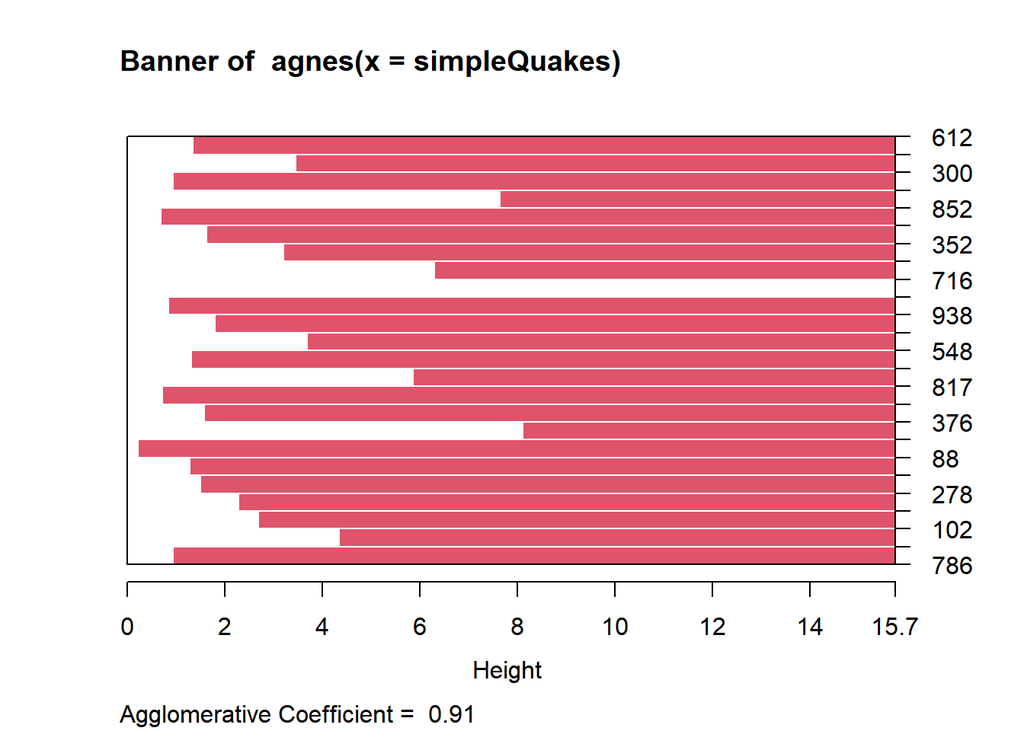

```r
# downsample quakes for demonstration. from 500 to 25
simpleQuakes <- quakes[sample(nrow(quakes),25),c("long","lat")]

plot(agnes(simpleQuakes), which.plots = 1) # banner plot
```

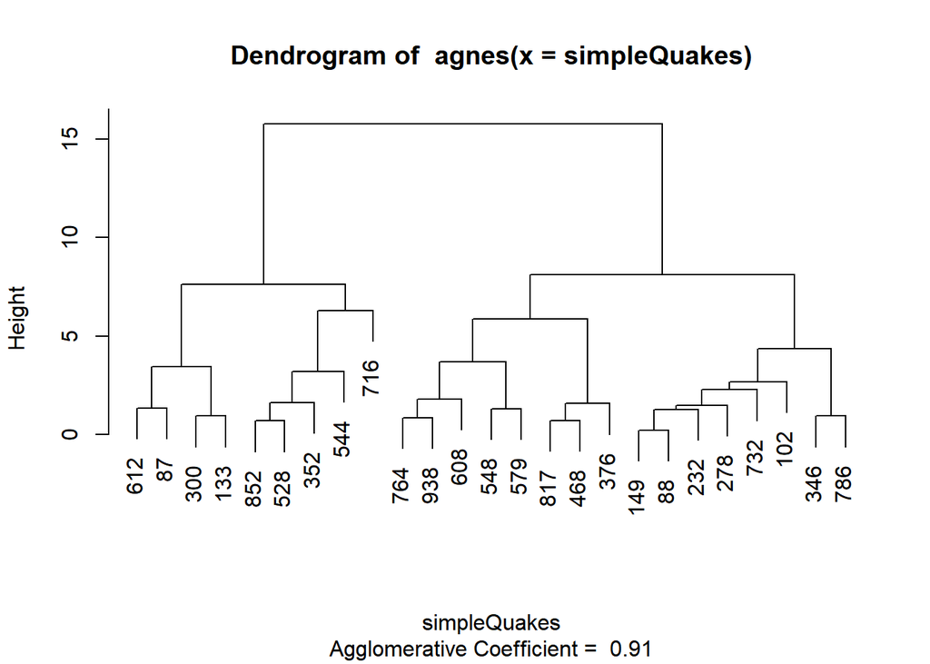

```r
plot(agnes(simpleQuakes), which.plots = 2) # dendogram
```

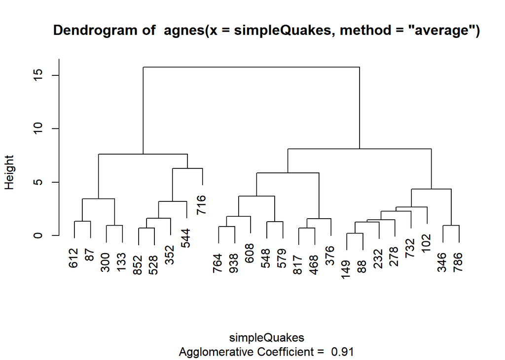

```r
# methods provided by agnes
plot(agnes(simpleQuakes, method = "average"), which.plots = 2)
```

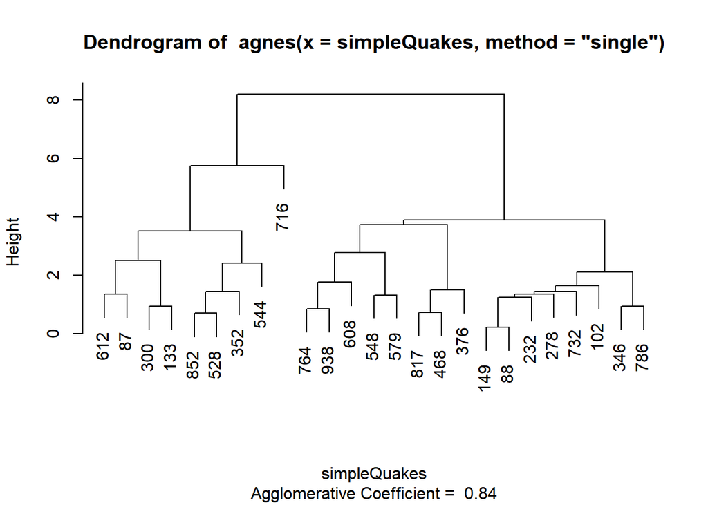

```r
plot(agnes(simpleQuakes, method = "single"), which.plots = 2)
```

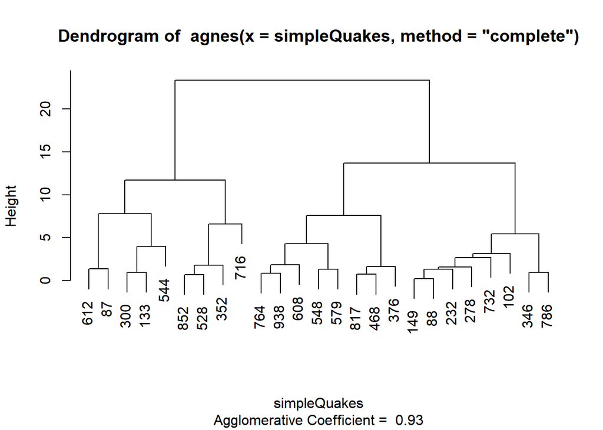

```r
plot(agnes(simpleQuakes, method = "complete"), which.plots = 2)
```

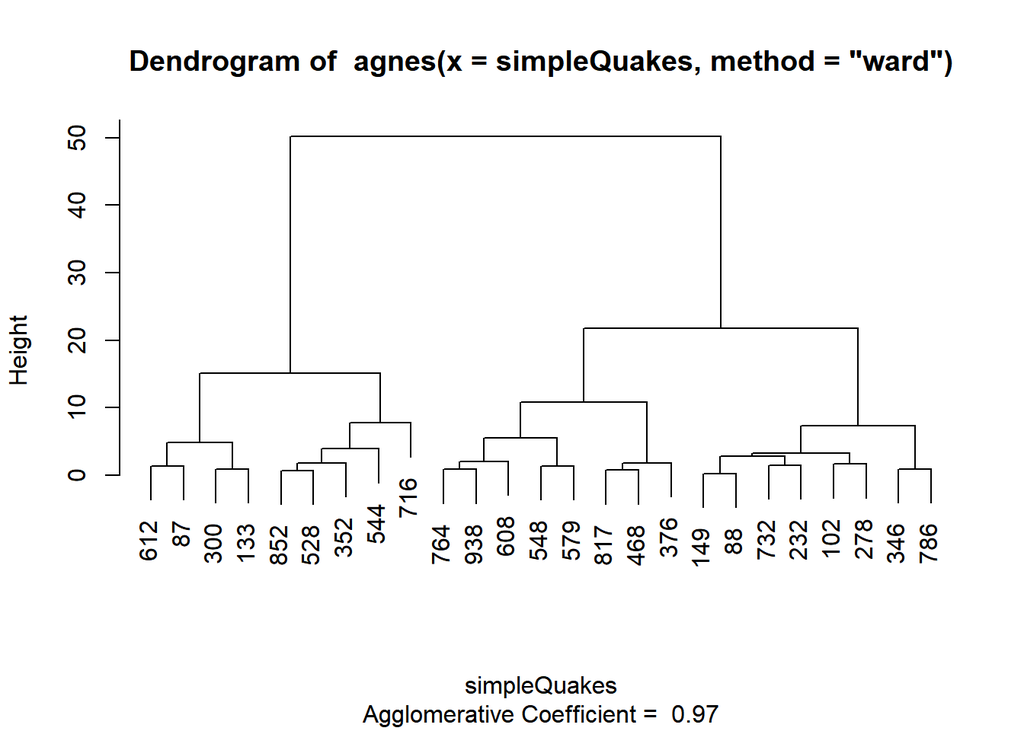

```r
plot(agnes(simpleQuakes, method = "ward"), which.plots = 2)
```

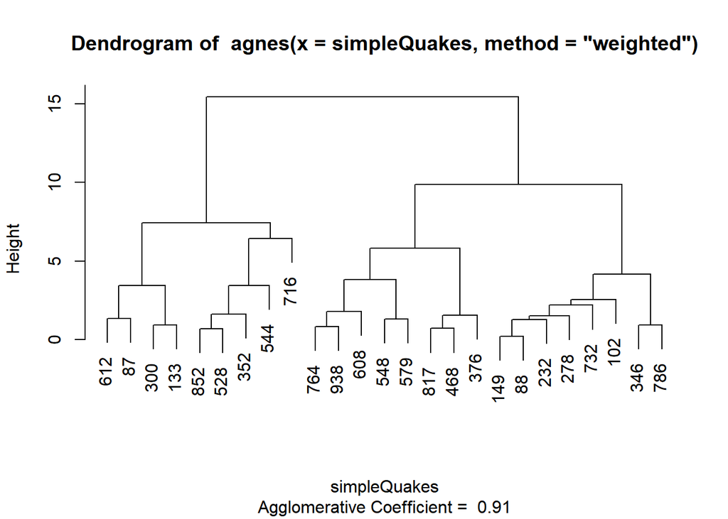

```r
plot(agnes(simpleQuakes, method = "weighted"), which.plots = 2)
```

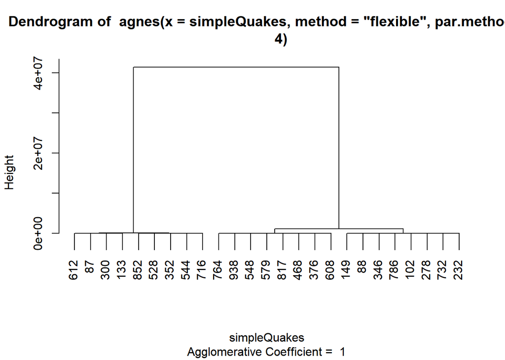

```r
plot(agnes(simpleQuakes, method = "flexible", par.method = 4), which.plots = 2)
```

## *mona* : MONothetic Analysis Clustering of Binary Variables

MONothetic analysis clustering of binary variables. Divisive (instead of Agglomerative). Focused on binary datasets

```r
# Titanic has three binary attributes

# convert titanic dataset from array to data.frame
#https://stackoverflow.com/questions/59447399/how-to-transform-the-titanic-data-set
d1 <- as.data.frame(Titanic)
Tita <- d1[rep(seq_len(nrow(d1)), d1$Freq),1:4]
row.names(Tita) <- NULL

# downsample for this example
smallTitanic <- Tita[sample(nrow(Tita), 30),
                     c("Sex","Age","Survived")]


monaTitanic <- mona(smallTitanic)
monaTitanic
```

```
## mona(x, ..) fit;  x of dimension 30x3
## Order of objects:
##  [1] 1267 1083 1024 696  1345 1190 973  1365 997  248  791  754  1196 586  168
## [16] 1130 966  616  910  29   1484 1471 1586 1575 1809 1749 1574 1735 1900 2178
## Variable used:
##  [1] NULL     NULL     NULL     NULL     NULL     NULL     NULL     NULL
##  [9] NULL     NULL     NULL     NULL     NULL     NULL     NULL     NULL
## [17] NULL     NULL     Age      Sex      NULL     Survived NULL     NULL
## [25] NULL     NULL     NULL     Sex      NULL
## Separation step:
##  [1] 0 0 0 0 0 0 0 0 0 0 0 0 0 0 0 0 0 0 3 2 0 1 0 0 0 0 0 2 0
##
## Available components:
## [1] "data"      "hasNA"     "order"     "variable"  "step"      "order.lab"
## [7] "call"
```

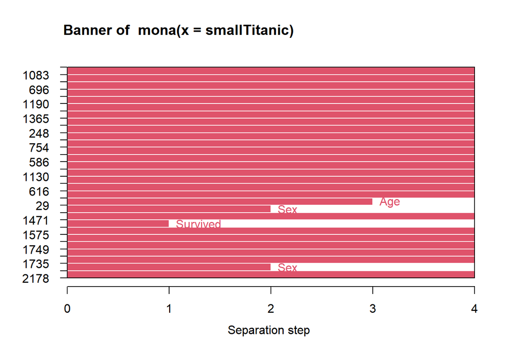

```r
plot(monaTitanic) # only bannerplot is available
```

```r
# examine mona object
data.frame("order"=monaTitanic$order,
           "Row Number"=monaTitanic$order.lab,
           "Split Variable"=c(monaTitanic$variable,"NULL"),
           "Step Level"=c(monaTitanic$step,"0")
)
```

| order | Row.Number | Split.Variable | Step.Level |
| --- | --- | --- | --- |
| 1 | 1267 | NULL | 0 |
| 2 | 1083 | NULL | 0 |
| 4 | 1024 | NULL | 0 |
| 5 | 696 | NULL | 0 |
| 6 | 1345 | NULL | 0 |
| 7 | 1190 | NULL | 0 |
| 8 | 973 | NULL | 0 |
| 10 | 1365 | NULL | 0 |
| 11 | 997 | NULL | 0 |
| 13 | 248 | NULL | 0 |

[output cut: 20 more lines]